# Unsupervised Learning Project

## Part A

To understand K-means Clustering by applying on the Car Dataset to segment the cars into various categories.

**Importing important modules**

```python
import numpy as np
import pandas as pd
import seaborn as sns
import matplotlib.pyplot as plt
from sklearn.preprocessing import LabelEncoder
from sklearn.model_selection import train_test_split
from sklearn.preprocessing import StandardScaler
from sklearn.svm import SVC
from sklearn.cluster import KMeans
from sklearn.decomposition import PCA
from sklearn.metrics import accuracy_score, confusion_matrix
from sklearn.metrics import classification_report
from sklearn import model_selection
from sklearn.metrics import accuracy_score, confusion_matrix
from sklearn.model_selection import GridSearchCV
from sklearn.metrics import classification_report
import warnings
warnings.filterwarnings("ignore")
```

**Read ‘Car name.csv’ as a DataFrame and assign it to a variable.**

```python
cn=pd.read_csv("Car name.csv")
cn.head(5)
```

|  | car_name |
| --- | --- |
| 0 | chevrolet chevelle malibu |
| 1 | buick skylark 320 |
| 2 | plymouth satellite |
| 3 | amc rebel sst |
| 4 | ford torino |

**Read ‘Car-Attributes.json as a DataFrame and assign it to a variable**

```python
ca = pd.read_json('Car-Attributes.json')
ca.head(5)
```

|  | mpg | cyl | disp | hp | wt | acc | yr | origin |
| --- | --- | --- | --- | --- | --- | --- | --- | --- |
| 0 | 18.0 | 8 | 307.0 | 130 | 3504 | 12.0 | 70 | 1 |
| 1 | 15.0 | 8 | 350.0 | 165 | 3693 | 11.5 | 70 | 1 |
| 2 | 18.0 | 8 | 318.0 | 150 | 3436 | 11.0 | 70 | 1 |
| 3 | 16.0 | 8 | 304.0 | 150 | 3433 | 12.0 | 70 | 1 |
| 4 | 17.0 | 8 | 302.0 | 140 | 3449 | 10.5 | 70 | 1 |

**Merge both the DataFrames together to form a single DataFrame**

```python
df=pd.concat([cn, ca], axis=1)
df.head(5)
```

|  | car_name | mpg | cyl | disp | hp | wt | acc | yr | origin |
| --- | --- | --- | --- | --- | --- | --- | --- | --- | --- |
| 0 | chevrolet chevelle malibu | 18.0 | 8 | 307.0 | 130 | 3504 | 12.0 | 70 | 1 |
| 1 | buick skylark 320 | 15.0 | 8 | 350.0 | 165 | 3693 | 11.5 | 70 | 1 |
| 2 | plymouth satellite | 18.0 | 8 | 318.0 | 150 | 3436 | 11.0 | 70 | 1 |
| 3 | amc rebel sst | 16.0 | 8 | 304.0 | 150 | 3433 | 12.0 | 70 | 1 |
| 4 | ford torino | 17.0 | 8 | 302.0 | 140 | 3449 | 10.5 | 70 | 1 |

**Print 5 point summary of the numerical features and share insights.**

```python
df.describe()
```

|  | mpg | cyl | disp | wt | acc | yr | origin |
| --- | --- | --- | --- | --- | --- | --- | --- |
| count | 398.000000 | 398.000000 | 398.000000 | 398.000000 | 398.000000 | 398.000000 | 398.000000 |
| mean | 23.514573 | 5.454774 | 193.425879 | 2970.424623 | 15.568090 | 76.010050 | 1.572864 |
| std | 7.815984 | 1.701004 | 104.269838 | 846.841774 | 2.757689 | 3.697627 | 0.802055 |
| min | 9.000000 | 3.000000 | 68.000000 | 1613.000000 | 8.000000 | 70.000000 | 1.000000 |
| 25% | 17.500000 | 4.000000 | 104.250000 | 2223.750000 | 13.825000 | 73.000000 | 1.000000 |
| 50% | 23.000000 | 4.000000 | 148.500000 | 2803.500000 | 15.500000 | 76.000000 | 1.000000 |
| 75% | 29.000000 | 8.000000 | 262.000000 | 3608.000000 | 17.175000 | 79.000000 | 2.000000 |
| max | 46.600000 | 8.000000 | 455.000000 | 5140.000000 | 24.800000 | 82.000000 | 3.000000 |

**mpg** mpg has equal mean and median.

minimum value is 9 maximum value is 46

75% data is less than 29

there may be some outliers, distubution can be assumed normal.

**cyl** cyl has diferent mean and median but difference is not bigger.

minimum value is 3 maximum value is 8

75% data is less than 8

**disp** disp has diferent mean and median difference is big.

75% data is less than 262

there are defintely outliers.

**wt** wt has diferent mean and median difference is big.

minimum value is 1613 maximum value is 5140

75% data is less than 3608

there are defintely outliers.

**acc** acc has equal mean and median.

minimum value is 8 maximum value is 24

75% data is less than 17

distrubution can be assumed normal.

**yr** yr has equal mean and median.

minimum value is 70 maximum value is 82

75% data is less than 79

distrubution can be assumed normal.

**Check and print feature-wise percentage of missing values present in the data and impute with the best suitable approach**

```python
df.isnull().sum()*100/len(df)
```

```
car_name    0.0
mpg         0.0
cyl         0.0
disp        0.0
hp          0.0
wt          0.0
acc         0.0
yr          0.0
origin      0.0
dtype: float64
```

There are no null values.

**Check for duplicate values in the data and impute with the best suitable approach.**

```python
df.duplicated().sum()
```

```
0
```

there are no duplicate values found.

**Plot a pairplot for all features.**

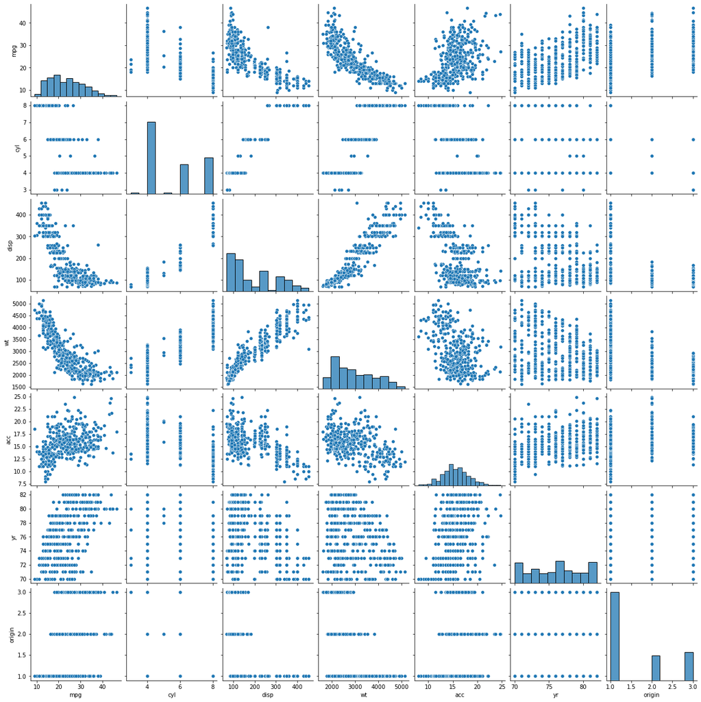

```python
sns.pairplot(df)
```

**Visualize a scatterplot for ‘wt’ and ‘disp’. Datapoints should be distinguishable by ‘cyl’**

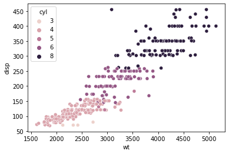

```python
sns.scatterplot(df['wt'],df['disp'], hue=df['cyl'])
```

**Share insights for Q2.d**

Both features looks positively correlated.

**Visualize a scatterplot for ‘wt’ and ’mpg’. Datapoints should be distinguishable by ‘cyl’.**

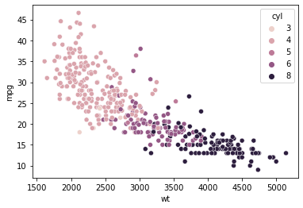

```python
sns.scatterplot(df['wt'],df['mpg'], hue=df['cyl'])
```

**Check for unexpected values in all the features and datapoints with such values.**

```python
df[df['hp']=="?"]
```

|  | car_name | mpg | cyl | disp | hp | wt | acc | yr | origin |
| --- | --- | --- | --- | --- | --- | --- | --- | --- | --- |
| 32 | ford pinto | 25.0 | 4 | 98.0 | ? | 2046 | 19.0 | 71 | 1 |
| 126 | ford maverick | 21.0 | 6 | 200.0 | ? | 2875 | 17.0 | 74 | 1 |
| 330 | renault lecar deluxe | 40.9 | 4 | 85.0 | ? | 1835 | 17.3 | 80 | 2 |
| 336 | ford mustang cobra | 23.6 | 4 | 140.0 | ? | 2905 | 14.3 | 80 | 1 |
| 354 | renault 18i | 34.5 | 4 | 100.0 | ? | 2320 | 15.8 | 81 | 2 |
| 374 | amc concord dl | 23.0 | 4 | 151.0 | ? | 3035 | 20.5 | 82 | 1 |

```python
df['hp'].replace("?",np.nan, inplace=True)
df.isna().sum()
```

```
car_name    0
mpg         0
cyl         0
disp        0
hp          6
wt          0
acc         0
yr          0
origin      0
dtype: int64
```

```python
hp=df['hp'].dropna()
hp.count()
```

```
392
```

```python
df['hp'].fillna((df['hp'].median()), inplace=True)
df['hp'] = df['hp'].astype('float')
```

**Apply K-Means clustering for 2 to 10 clusters.**

Removing unnecessary columns and standardizing the data

```python
df['age'] = 83-df['yr']
df.head()
```

|  | car_name | mpg | cyl | disp | hp | wt | acc | yr | origin | age |
| --- | --- | --- | --- | --- | --- | --- | --- | --- | --- | --- |
| 0 | chevrolet chevelle malibu | 18.0 | 8 | 307.0 | 130.0 | 3504 | 12.0 | 70 | 1 | 13 |
| 1 | buick skylark 320 | 15.0 | 8 | 350.0 | 165.0 | 3693 | 11.5 | 70 | 1 | 13 |
| 2 | plymouth satellite | 18.0 | 8 | 318.0 | 150.0 | 3436 | 11.0 | 70 | 1 | 13 |
| 3 | amc rebel sst | 16.0 | 8 | 304.0 | 150.0 | 3433 | 12.0 | 70 | 1 | 13 |
| 4 | ford torino | 17.0 | 8 | 302.0 | 140.0 | 3449 | 10.5 | 70 | 1 | 13 |

```python
df1=df.drop(['yr','car_name'], axis =1)
df1
```

|  | mpg | cyl | disp | hp | wt | acc | origin | age |
| --- | --- | --- | --- | --- | --- | --- | --- | --- |
| 0 | 18.0 | 8 | 307.0 | 130.0 | 3504 | 12.0 | 1 | 13 |
| 1 | 15.0 | 8 | 350.0 | 165.0 | 3693 | 11.5 | 1 | 13 |
| 2 | 18.0 | 8 | 318.0 | 150.0 | 3436 | 11.0 | 1 | 13 |
| 3 | 16.0 | 8 | 304.0 | 150.0 | 3433 | 12.0 | 1 | 13 |
| 4 | 17.0 | 8 | 302.0 | 140.0 | 3449 | 10.5 | 1 | 13 |
| ... | ... | ... | ... | ... | ... | ... | ... | ... |
| 393 | 27.0 | 4 | 140.0 | 86.0 | 2790 | 15.6 | 1 | 1 |
| 394 | 44.0 | 4 | 97.0 | 52.0 | 2130 | 24.6 | 2 | 1 |
| 395 | 32.0 | 4 | 135.0 | 84.0 | 2295 | 11.6 | 1 | 1 |
| 396 | 28.0 | 4 | 120.0 | 79.0 | 2625 | 18.6 | 1 | 1 |
| 397 | 31.0 | 4 | 119.0 | 82.0 | 2720 | 19.4 | 1 | 1 |

398 rows × 8 columns

```python
df1['hp'] = np.log(df1['hp'])
df1['acc'] = np.log(df1['acc'])
df1['mpg'] = np.log(df1['mpg'])

df1.head()
```

|  | mpg | cyl | disp | hp | wt | acc | origin | age |
| --- | --- | --- | --- | --- | --- | --- | --- | --- |
| 0 | 2.890372 | 8 | 307.0 | 4.867534 | 3504 | 2.484907 | 1 | 13 |
| 1 | 2.708050 | 8 | 350.0 | 5.105945 | 3693 | 2.442347 | 1 | 13 |
| 2 | 2.890372 | 8 | 318.0 | 5.010635 | 3436 | 2.397895 | 1 | 13 |
| 3 | 2.772589 | 8 | 304.0 | 5.010635 | 3433 | 2.484907 | 1 | 13 |
| 4 | 2.833213 | 8 | 302.0 | 4.941642 | 3449 | 2.351375 | 1 | 13 |

```python
scaler = StandardScaler()
df1[['mpg','cyl','disp','hp','wt','acc','age']] = scaler.fit_transform(df1[['mpg','cyl','disp','hp','wt','acc','age']])
df1.head()
```

|  | mpg | cyl | disp | hp | wt | acc | origin | age |
| --- | --- | --- | --- | --- | --- | --- | --- | --- |
| 0 | -0.622035 | 1.498191 | 1.090604 | 0.823608 | 0.630870 | -1.353748 | 1 | 1.627426 |
| 1 | -1.159493 | 1.498191 | 1.503514 | 1.523992 | 0.854333 | -1.589535 | 1 | 1.627426 |
| 2 | -0.622035 | 1.498191 | 1.196232 | 1.243998 | 0.550470 | -1.835805 | 1 | 1.627426 |
| 3 | -0.969242 | 1.498191 | 1.061796 | 1.243998 | 0.546923 | -1.353748 | 1 | 1.627426 |
| 4 | -0.790530 | 1.498191 | 1.042591 | 1.041316 | 0.565841 | -2.093533 | 1 | 1.627426 |

```python
cluster_range = range(2,11)
cluster_errors = []
for num_clusters in cluster_range:
    clusters = KMeans(num_clusters, n_init = 5)
    clusters.fit(df1)
    labels = clusters.labels_
    centroids = clusters.cluster_centers_
    cluster_errors.append(clusters.inertia_)

clusters_df = pd.DataFrame({"num_clusters": cluster_range, "cluster_errors": cluster_errors})
clusters_df
```

|  | num_clusters | cluster_errors |
| --- | --- | --- |
| 0 | 2 | 1455.063544 |
| 1 | 3 | 1080.088283 |
| 2 | 4 | 884.999519 |
| 3 | 5 | 776.094756 |
| 4 | 6 | 708.318661 |
| 5 | 7 | 662.016818 |
| 6 | 8 | 606.897124 |
| 7 | 9 | 566.897965 |
| 8 | 10 | 528.076106 |

**Plot a visual and find elbow point.**

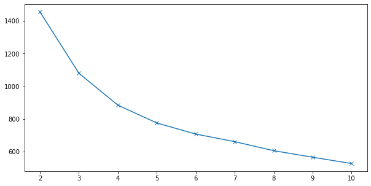

```python
from matplotlib import cm

plt.figure(figsize=(10,5))
plt.plot( clusters_df.num_clusters, clusters_df.cluster_errors, marker = "x" )
```

**On the above visual, highlight which are the possible Elbow points.**

possible clusters can be around 3 to 5.

**Train a K-means clustering model once again on the optimal number of clusters**

```python
kmeans = KMeans(n_clusters=3, n_init = 5, random_state=100)
y=kmeans.fit(df1)
```

```python
# let us check the centers in each group
centroids = kmeans.cluster_centers_
centroid_df = pd.DataFrame(centroids, columns = list(df1) )
centroid_df.transpose()
```

|  | 0 | 1 | 2 |
| --- | --- | --- | --- |
| mpg | -1.306300 | 0.737630 | -0.402227 |
| cyl | 1.498191 | -0.831680 | 0.426756 |
| disp | 1.503923 | -0.795498 | 0.333295 |
| hp | 1.442656 | -0.672324 | 0.100451 |
| wt | 1.404098 | -0.753936 | 0.338326 |
| acc | -1.150226 | 0.361362 | 0.341891 |
| origin | 1.000000 | 2.023256 | 1.089888 |
| age | 0.688324 | -0.312144 | 0.027062 |

**Add a new feature in the DataFrame which will have labels based upon cluster value**

```python
predictions = kmeans.predict(df1)
predictions
df["group"] = predictions
df['group'] = df['group'].astype('category')
```

```python
df
```

|  | car_name | mpg | cyl | disp | hp | wt | acc | yr | origin | age | group |
| --- | --- | --- | --- | --- | --- | --- | --- | --- | --- | --- | --- |
| 0 | chevrolet chevelle malibu | 18.0 | 8 | 307.0 | 130.0 | 3504 | 12.0 | 70 | 1 | 13 | 0 |
| 1 | buick skylark 320 | 15.0 | 8 | 350.0 | 165.0 | 3693 | 11.5 | 70 | 1 | 13 | 0 |
| 2 | plymouth satellite | 18.0 | 8 | 318.0 | 150.0 | 3436 | 11.0 | 70 | 1 | 13 | 0 |
| 3 | amc rebel sst | 16.0 | 8 | 304.0 | 150.0 | 3433 | 12.0 | 70 | 1 | 13 | 0 |
| 4 | ford torino | 17.0 | 8 | 302.0 | 140.0 | 3449 | 10.5 | 70 | 1 | 13 | 0 |
| ... | ... | ... | ... | ... | ... | ... | ... | ... | ... | ... | ... |
| 393 | ford mustang gl | 27.0 | 4 | 140.0 | 86.0 | 2790 | 15.6 | 82 | 1 | 1 | 1 |
| 394 | vw pickup | 44.0 | 4 | 97.0 | 52.0 | 2130 | 24.6 | 82 | 2 | 1 | 1 |
| 395 | dodge rampage | 32.0 | 4 | 135.0 | 84.0 | 2295 | 11.6 | 82 | 1 | 1 | 1 |
| 396 | ford ranger | 28.0 | 4 | 120.0 | 79.0 | 2625 | 18.6 | 82 | 1 | 1 | 1 |
| 397 | chevy s-10 | 31.0 | 4 | 119.0 | 82.0 | 2720 | 19.4 | 82 | 1 | 1 | 1 |

398 rows × 11 columns

**Plot a visual and color the datapoints based upon clusters.**

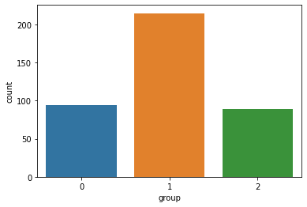

```python
sns.countplot(df['group'])
```

cluster 1 has more datapoints then other two but distrubution looks normal.

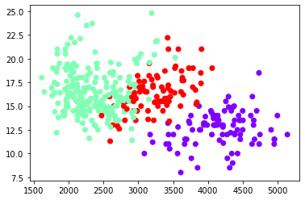

```python
plt.scatter(df['wt'],df['acc'],c=df['group'],cmap='rainbow')
plt.show()
```

**Pass a new DataPoint and predict which cluster it belongs to.**

```python
data=[[-0.969242,1.498191,1.061796,1.243998,0.546923,-1.353748,1,1.627426]]
df2 = pd.DataFrame(data, columns = [ 'mpg', 'cyl', 'disp', 'hp', 'wt', 'acc','origin','age'])
```

```python
pred=kmeans.predict(df2)
pred
```

```
array([0])
```

After predicting for one datapoint we fount it belongs to cluster 0.

## Part B

**Read ‘vehicle.csv’ and save as DataFrame**

```python
ve=pd.read_csv("vehicle.csv")
```

```python
ve.head()
```

|  | compactness | circularity | distance_circularity | radius_ratio | pr.axis_aspect_ratio | max.length_aspect_ratio | scatter_ratio | elongatedness | pr.axis_rectangularity | max.length_rectangularity | scaled_variance | scaled_variance.1 | scaled_radius_of_gyration | scaled_radius_of_gyration.1 | skewness_about | skewness_about.1 | skewness_about.2 | hollows_ratio | class |
| --- | --- | --- | --- | --- | --- | --- | --- | --- | --- | --- | --- | --- | --- | --- | --- | --- | --- | --- | --- |
| 0 | 95 | 48.0 | 83.0 | 178.0 | 72.0 | 10 | 162.0 | 42.0 | 20.0 | 159 | 176.0 | 379.0 | 184.0 | 70.0 | 6.0 | 16.0 | 187.0 | 197 | van |
| 1 | 91 | 41.0 | 84.0 | 141.0 | 57.0 | 9 | 149.0 | 45.0 | 19.0 | 143 | 170.0 | 330.0 | 158.0 | 72.0 | 9.0 | 14.0 | 189.0 | 199 | van |
| 2 | 104 | 50.0 | 106.0 | 209.0 | 66.0 | 10 | 207.0 | 32.0 | 23.0 | 158 | 223.0 | 635.0 | 220.0 | 73.0 | 14.0 | 9.0 | 188.0 | 196 | car |
| 3 | 93 | 41.0 | 82.0 | 159.0 | 63.0 | 9 | 144.0 | 46.0 | 19.0 | 143 | 160.0 | 309.0 | 127.0 | 63.0 | 6.0 | 10.0 | 199.0 | 207 | van |
| 4 | 85 | 44.0 | 70.0 | 205.0 | 103.0 | 52 | 149.0 | 45.0 | 19.0 | 144 | 241.0 | 325.0 | 188.0 | 127.0 | 9.0 | 11.0 | 180.0 | 183 | bus |

**Check percentage of missing values and impute with correct approach.**

```python
(ve.isnull().sum()/len(ve))*100
```

```
compactness                    0.000000
circularity                    0.591017
distance_circularity           0.472813
radius_ratio                   0.709220
pr.axis_aspect_ratio           0.236407
max.length_aspect_ratio        0.000000
scatter_ratio                  0.118203
elongatedness                  0.118203
pr.axis_rectangularity         0.354610
max.length_rectangularity      0.000000
scaled_variance                0.354610
scaled_variance.1              0.236407
scaled_radius_of_gyration      0.236407
scaled_radius_of_gyration.1    0.472813
skewness_about                 0.709220
skewness_about.1               0.118203
skewness_about.2               0.118203
hollows_ratio                  0.000000
class                          0.000000
dtype: float64
```

```python
li=['circularity','distance_circularity','radius_ratio','pr.axis_aspect_ratio','scatter_ratio','elongatedness','pr.axis_rectangularity','max.length_rectangularity'
   ,'scaled_variance','scaled_variance.1','scaled_radius_of_gyration','scaled_radius_of_gyration.1','skewness_about','skewness_about.1','skewness_about.2']
for i in li:
    ve[i].fillna((ve[i].median()), inplace=True)
    ve[i] = ve[i].astype('float')
```

```python
ve.isnull().sum()
```

```
compactness                    0
circularity                    0
distance_circularity           0
radius_ratio                   0
pr.axis_aspect_ratio           0
max.length_aspect_ratio        0
scatter_ratio                  0
elongatedness                  0
pr.axis_rectangularity         0
max.length_rectangularity      0
scaled_variance                0
scaled_variance.1              0
scaled_radius_of_gyration      0
scaled_radius_of_gyration.1    0
skewness_about                 0
skewness_about.1               0
skewness_about.2               0
hollows_ratio                  0
class                          0
dtype: int64
```

imuted null values with median values

**Visualize a Pie-chart and print percentage of values for variable ‘class’.**

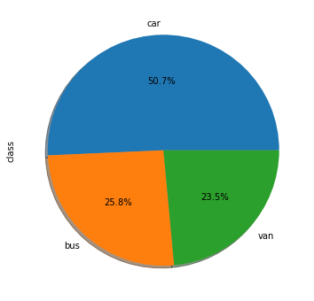

```python
plt.figure(figsize=(10,6))
ve['class'].value_counts().plot.pie(autopct='%1.1f%%',shadow=True)
```

**Check for duplicate rows in the data and impute with correct approach.**

```python
ve.duplicated().sum()
```

```
0
```

there are no duplicate values

**Split data into X and Y**

```python
le =LabelEncoder()
ve['class']=le.fit_transform(ve['class'])
```

```python
X=ve.drop(columns='class')
y=ve['class'] #target variable
```

```python
X.head()
```

|  | compactness | circularity | distance_circularity | radius_ratio | pr.axis_aspect_ratio | max.length_aspect_ratio | scatter_ratio | elongatedness | pr.axis_rectangularity | max.length_rectangularity | scaled_variance | scaled_variance.1 | scaled_radius_of_gyration | scaled_radius_of_gyration.1 | skewness_about | skewness_about.1 | skewness_about.2 | hollows_ratio |
| --- | --- | --- | --- | --- | --- | --- | --- | --- | --- | --- | --- | --- | --- | --- | --- | --- | --- | --- |
| 0 | 95 | 48.0 | 83.0 | 178.0 | 72.0 | 10 | 162.0 | 42.0 | 20.0 | 159.0 | 176.0 | 379.0 | 184.0 | 70.0 | 6.0 | 16.0 | 187.0 | 197 |
| 1 | 91 | 41.0 | 84.0 | 141.0 | 57.0 | 9 | 149.0 | 45.0 | 19.0 | 143.0 | 170.0 | 330.0 | 158.0 | 72.0 | 9.0 | 14.0 | 189.0 | 199 |
| 2 | 104 | 50.0 | 106.0 | 209.0 | 66.0 | 10 | 207.0 | 32.0 | 23.0 | 158.0 | 223.0 | 635.0 | 220.0 | 73.0 | 14.0 | 9.0 | 188.0 | 196 |
| 3 | 93 | 41.0 | 82.0 | 159.0 | 63.0 | 9 | 144.0 | 46.0 | 19.0 | 143.0 | 160.0 | 309.0 | 127.0 | 63.0 | 6.0 | 10.0 | 199.0 | 207 |
| 4 | 85 | 44.0 | 70.0 | 205.0 | 103.0 | 52 | 149.0 | 45.0 | 19.0 | 144.0 | 241.0 | 325.0 | 188.0 | 127.0 | 9.0 | 11.0 | 180.0 | 183 |

```python
y.head()
```

```
0    2
1    2
2    1
3    2
4    0
Name: class, dtype: int32
```

**Standardize the Data.**

```python
from scipy.stats import zscore
XScaled=X.apply(zscore)
XScaled.head()
```

|  | compactness | circularity | distance_circularity | radius_ratio | pr.axis_aspect_ratio | max.length_aspect_ratio | scatter_ratio | elongatedness | pr.axis_rectangularity | max.length_rectangularity | scaled_variance | scaled_variance.1 | scaled_radius_of_gyration | scaled_radius_of_gyration.1 | skewness_about | skewness_about.1 | skewness_about.2 | hollows_ratio |
| --- | --- | --- | --- | --- | --- | --- | --- | --- | --- | --- | --- | --- | --- | --- | --- | --- | --- | --- |
| 0 | 0.160580 | 0.518073 | 0.057177 | 0.273363 | 1.310398 | 0.311542 | -0.207598 | 0.136262 | -0.224342 | 0.758332 | -0.401920 | -0.341934 | 0.285705 | -0.327326 | -0.073812 | 0.380870 | -0.312012 | 0.183957 |
| 1 | -0.325470 | -0.623732 | 0.120741 | -0.835032 | -0.593753 | 0.094079 | -0.599423 | 0.520519 | -0.610886 | -0.344578 | -0.593357 | -0.619724 | -0.513630 | -0.059384 | 0.538390 | 0.156798 | 0.013265 | 0.452977 |
| 2 | 1.254193 | 0.844303 | 1.519141 | 1.202018 | 0.548738 | 0.311542 | 1.148719 | -1.144597 | 0.935290 | 0.689401 | 1.097671 | 1.109379 | 1.392477 | 0.074587 | 1.558727 | -0.403383 | -0.149374 | 0.049447 |
| 3 | -0.082445 | -0.623732 | -0.006386 | -0.295813 | 0.167907 | 0.094079 | -0.750125 | 0.648605 | -0.610886 | -0.344578 | -0.912419 | -0.738777 | -1.466683 | -1.265121 | -0.073812 | -0.291347 | 1.639649 | 1.529056 |
| 4 | -1.054545 | -0.134387 | -0.769150 | 1.082192 | 5.245643 | 9.444962 | -0.599423 | 0.520519 | -0.610886 | -0.275646 | 1.671982 | -0.648070 | 0.408680 | 7.309005 | 0.538390 | -0.179311 | -1.450481 | -1.699181 |

```python
X_train, X_test, y_train, y_test = train_test_split(XScaled, y, test_size=0.30, random_state=100)
```

**Train a base Classification model using SVM**

```python
SVM = SVC()
SVM.fit(X_train,y_train)
preds = SVM.predict(X_test)
preds2 = SVM.predict(X_train)
srsvm=SVM.score(X_test, y_test)
print("Accuracy of SVM",srsvm*100)
```

```
Accuracy of SVM 95.2755905511811
```

**Print Classification metrics for train data.**

```
confusion matrix for train data
```

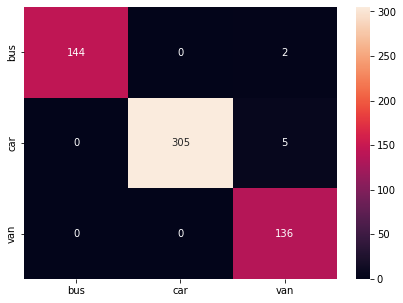

```python
print("confusion matrix for train data")
cm = confusion_matrix(y_train, preds2, labels=[0,1,2])
df_cm = pd.DataFrame(cm, index = [i for i in ['bus','car','van']],
                  columns = [i for i in ['bus','car','van']])
plt.figure(figsize = (7,5))
sns.heatmap(df_cm, annot=True ,fmt='g')
plt.show()
```

```python
print("classification  Matrix of training data:\n",classification_report(y_train,preds2))
```

```
classification  Matrix of training data:
               precision    recall  f1-score   support

           0       1.00      0.99      0.99       146
           1       1.00      0.98      0.99       310
           2       0.95      1.00      0.97       136

    accuracy                           0.99       592
   macro avg       0.98      0.99      0.99       592
weighted avg       0.99      0.99      0.99       592
```

```
confusion matrix for test data
```

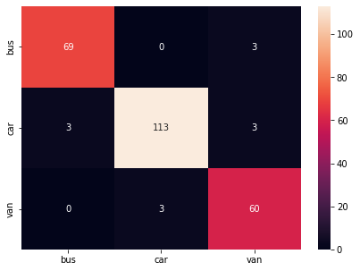

```python
print("confusion matrix for test data")
cm = confusion_matrix(y_test, preds, labels=[0,1,2])
df_cm = pd.DataFrame(cm, index = [i for i in ['bus','car','van']],
                  columns = [i for i in ['bus','car','van']])
plt.figure(figsize = (7,5))
sns.heatmap(df_cm, annot=True ,fmt='g')
plt.show()
```

```python
print("classification  Matrix of testing data:\n",classification_report(y_test,preds))
```

```
classification  Matrix of testing data:
               precision    recall  f1-score   support

           0       0.96      0.96      0.96        72
           1       0.97      0.95      0.96       119
           2       0.91      0.95      0.93        63

    accuracy                           0.95       254
   macro avg       0.95      0.95      0.95       254
weighted avg       0.95      0.95      0.95       254
```

Accuracy and precision for all classes is good.

**Apply PCA on the data with 10 components.**

```python
pca = PCA(n_components=10)
pca.fit(XScaled)
```

```
PCA(n_components=10)
```

**Visualize Cumulative Variance Explained with Number of Components.**

```python
pca.explained_variance_
```

```
array([9.40460261, 3.01492206, 1.90352502, 1.17993747, 0.91726063,
       0.53999263, 0.35887012, 0.22193246, 0.1606086 , 0.09185722])
```

```python
cvr=pca.explained_variance_ratio_*100
```

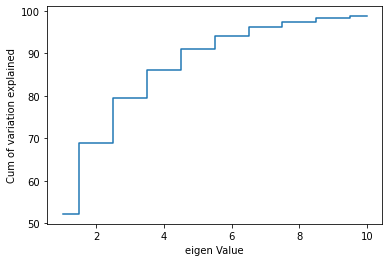

```python
plt.step(list(range(1,11)),np.cumsum(cvr), where='mid')
plt.ylabel('Cum of variation explained')
plt.xlabel('eigen Value')
plt.show()
```

almost 100% of variation is explained by eigen value 10.

**Draw a horizontal line on the above plot to highlight the threshold of 90%**

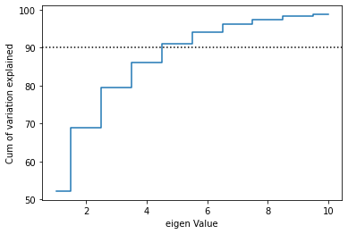

```python
plt.step(list(range(1,11)),np.cumsum(cvr), where='mid')
plt.ylabel('Cum of variation explained')
plt.axhline(90,color ='black',ls='dotted')
plt.xlabel('eigen Value')
plt.show()
```

**Apply PCA on the data. This time Select Minimum Components with 90% or above variance explained.**

minimum components required to cross the threshold is 5

```python
pca2 = PCA(n_components=5)
pca2.fit(XScaled)
print(pca2.components_)
print(pca2.explained_variance_ratio_)
xpca = pca2.transform(XScaled)
```

```
[[ 2.75283688e-01  2.93258469e-01  3.04609128e-01  2.67606877e-01
   8.05039890e-02  9.72756855e-02  3.17092750e-01 -3.14133155e-01
   3.13959064e-01  2.82830900e-01  3.09280359e-01  3.13788457e-01
   2.72047492e-01 -2.08137692e-02  4.14555082e-02  5.82250207e-02
   3.02795063e-02  7.41453913e-02]
 [-1.26953763e-01  1.25576727e-01 -7.29516436e-02 -1.89634378e-01
  -1.22174860e-01  1.07482875e-02  4.81181371e-02  1.27498515e-02
   5.99352482e-02  1.16220532e-01  6.22806229e-02  5.37843596e-02
   2.09233172e-01  4.88525148e-01 -5.50899716e-02 -1.24085090e-01
  -5.40914775e-01 -5.40354258e-01]
 [-1.19922479e-01 -2.48205467e-02 -5.60143254e-02  2.75074210e-01
   6.42012966e-01  5.91801304e-01 -9.76283108e-02  5.76484384e-02
  -1.09512416e-01 -1.70641987e-02  5.63239801e-02 -1.08840729e-01
  -3.14636493e-02  2.86277015e-01 -1.15679354e-01 -7.52828901e-02
   8.73592035e-03  3.95242743e-02]
 [ 7.83843562e-02  1.87337408e-01 -7.12008427e-02 -4.26053413e-02
   3.27257119e-02  3.14147276e-02 -9.57485748e-02  8.22901953e-02
  -9.24582989e-02  1.88005612e-01 -1.19844008e-01 -9.17449326e-02
   2.00095228e-01 -6.55051355e-02  6.04794251e-01 -6.66114117e-01
   1.05526253e-01  4.74890311e-02]
 [ 6.95178334e-02 -8.50649565e-02  4.06645648e-02 -4.61473700e-02
  -4.05494494e-02  2.13432565e-01 -1.54853057e-02  7.68518715e-02
   2.17633136e-03 -6.06366825e-02 -4.56471655e-04 -1.95548319e-02
  -6.15991675e-02  1.45530146e-01  7.29189842e-01  5.99196401e-01
  -1.00602332e-01 -2.98614819e-02]]
[0.52186034 0.16729768 0.10562639 0.0654746  0.05089869]
```

**Train SVM model on components selected from above step.**

```python
xtrain, xtest, ytrain, ytest = train_test_split(xpca,y,test_size=0.30, random_state=1)
```

```python
SVM.fit(xtrain,ytrain)
preds3 = SVM.predict(xtest)
preds4 = SVM.predict(xtrain)
srsvm2=SVM.score(xtest, ytest)
print("Accuracy of SVM",srsvm2*100)
```

```
Accuracy of SVM 77.55905511811024
```

**Print Classification metrics for train data of above model and share insight**

```
confusion matrix for train data
```

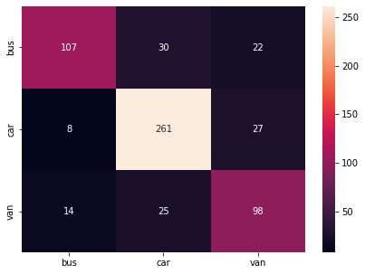

```python
print("confusion matrix for train data")
cm = confusion_matrix(ytrain, preds4, labels=[0,1,2])
df_cm = pd.DataFrame(cm, index = [i for i in ['bus','car','van']],
                  columns = [i for i in ['bus','car','van']])
plt.figure(figsize = (7,5))
sns.heatmap(df_cm, annot=True ,fmt='g')
plt.show()
```

```python
print("classification  Matrix of testing data:\n",classification_report(ytrain,preds4))
```

```
classification  Matrix of testing data:
               precision    recall  f1-score   support

           0       0.83      0.67      0.74       159
           1       0.83      0.88      0.85       296
           2       0.67      0.72      0.69       137

    accuracy                           0.79       592
   macro avg       0.77      0.76      0.76       592
weighted avg       0.79      0.79      0.79       592
```

```
confusion matrix for test data
```

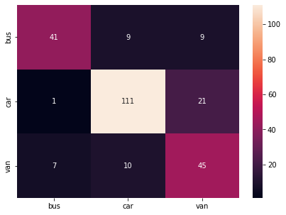

```python
print("confusion matrix for test data")
cm = confusion_matrix(ytest, preds3, labels=[0,1,2])
df_cm = pd.DataFrame(cm, index = [i for i in ['bus','car','van']],
                  columns = [i for i in ['bus','car','van']])
plt.figure(figsize = (7,5))
sns.heatmap(df_cm, annot=True ,fmt='g')
plt.show()
```

```python
print("classification  Matrix of testing data:\n",classification_report(ytest,preds3))
```

```
classification  Matrix of testing data:
               precision    recall  f1-score   support

           0       0.84      0.69      0.76        59
           1       0.85      0.83      0.84       133
           2       0.60      0.73      0.66        62

    accuracy                           0.78       254
   macro avg       0.76      0.75      0.75       254
weighted avg       0.79      0.78      0.78       254
```

we are taking 5 components in considration here,accuracy is decreased to accuracy which we got with 18 components.

we can clearly observe that using pca we were able to reduce dimensions from 18 to 5, although accuracy is effected but svm model is trained faster.

**Train another SVM on the components out of PCA. Tune the parameters to improve performance.**

Performing hyperparameter tunning for finding best model.

```python
clf=SVC()
param_grid = {'C': [0.1, 1, 10, 100, 1000],
              'gamma': [1, 0.1, 0.01, 0.001, 0.0001],
              'kernel': ['rbf']}
grid = GridSearchCV(clf, param_grid, refit = True, verbose = 3)
```

```python
grid.fit(xtrain, ytrain)
```

[output not shown]

[output cut: 71 more lines]

```
[CV 1/5] END ....C=1000, gamma=0.01, kernel=rbf;, score=0.790 total time=   0.0s
[CV 2/5] END ....C=1000, gamma=0.01, kernel=rbf;, score=0.782 total time=   0.0s
[CV 3/5] END ....C=1000, gamma=0.01, kernel=rbf;, score=0.797 total time=   0.0s
[CV 4/5] END ....C=1000, gamma=0.01, kernel=rbf;, score=0.771 total time=   0.0s
[CV 5/5] END ....C=1000, gamma=0.01, kernel=rbf;, score=0.746 total time=   0.0s
[CV 1/5] END ...C=1000, gamma=0.001, kernel=rbf;, score=0.731 total time=   0.0s
[CV 2/5] END ...C=1000, gamma=0.001, kernel=rbf;, score=0.689 total time=   0.0s
[CV 3/5] END ...C=1000, gamma=0.001, kernel=rbf;, score=0.746 total time=   0.0s
[CV 4/5] END ...C=1000, gamma=0.001, kernel=rbf;, score=0.780 total time=   0.0s
[CV 5/5] END ...C=1000, gamma=0.001, kernel=rbf;, score=0.653 total time=   0.0s
[CV 1/5] END ..C=1000, gamma=0.0001, kernel=rbf;, score=0.714 total time=   0.0s
[CV 2/5] END ..C=1000, gamma=0.0001, kernel=rbf;, score=0.647 total time=   0.0s
[CV 3/5] END ..C=1000, gamma=0.0001, kernel=rbf;, score=0.644 total time=   0.0s
[CV 4/5] END ..C=1000, gamma=0.0001, kernel=rbf;, score=0.712 total time=   0.0s
[CV 5/5] END ..C=1000, gamma=0.0001, kernel=rbf;, score=0.619 total time=   0.0s
```

```
GridSearchCV(estimator=SVC(),
             param_grid={'C': [0.1, 1, 10, 100, 1000],
                         'gamma': [1, 0.1, 0.01, 0.001, 0.0001],
                         'kernel': ['rbf']},
             verbose=3)
```

```python
# print best parameter after tuning
print(grid.best_params_)

# print how our model looks after hyper-parameter tuning
print(grid.best_estimator_)
```

```
{'C': 1000, 'gamma': 0.01, 'kernel': 'rbf'}
SVC(C=1000, gamma=0.01)
```

```python
clf1=SVC( C=1000, gamma=0.01,kernel ='rbf')
clf1.fit(xtrain,ytrain)
predictions = clf1.predict(xtest)
predictions2 = clf1.predict(xtrain)
sr=clf1.score(xtest, ytest)
print("Accuracy of SVM",sr*100)
```

```
Accuracy of SVM 83.85826771653542
```

**Share best Parameters observed from above step**

```python
print(grid.best_params_)
```

```
{'C': 1000, 'gamma': 0.01, 'kernel': 'rbf'}
```

**Print Classification metrics for train data of above model and share relative improvement in performance in all the models along with insights.**

```
confusion matrix for train data
```

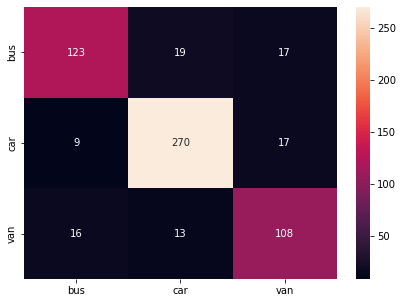

```python
print("confusion matrix for train data")
cm = confusion_matrix(ytrain, predictions2, labels=[0,1,2])
df_cm = pd.DataFrame(cm, index = [i for i in ['bus','car','van']],
                  columns = [i for i in ['bus','car','van']])
plt.figure(figsize = (7,5))
sns.heatmap(df_cm, annot=True ,fmt='g')
plt.show()
```

```python
print("classification  Matrix of training data:\n",classification_report(ytrain,predictions2))
```

```
classification  Matrix of training data:
               precision    recall  f1-score   support

           0       0.83      0.77      0.80       159
           1       0.89      0.91      0.90       296
           2       0.76      0.79      0.77       137

    accuracy                           0.85       592
   macro avg       0.83      0.82      0.83       592
weighted avg       0.85      0.85      0.85       592
```

```
confusion matrix for test data
```

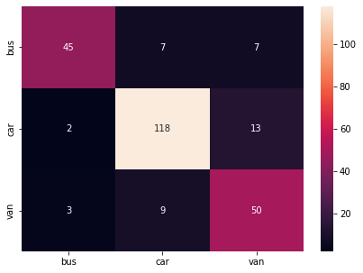

```python
print("confusion matrix for test data")
cm = confusion_matrix(ytest, predictions, labels=[0,1,2])
df_cm = pd.DataFrame(cm, index = [i for i in ['bus','car','van']],
                  columns = [i for i in ['bus','car','van']])
plt.figure(figsize = (7,5))
sns.heatmap(df_cm, annot=True ,fmt='g')
plt.show()
```

```python
print(classification_report(ytest, predictions))
```

```
              precision    recall  f1-score   support

           0       0.90      0.76      0.83        59
           1       0.88      0.89      0.88       133
           2       0.71      0.81      0.76        62

    accuracy                           0.84       254
   macro avg       0.83      0.82      0.82       254
weighted avg       0.84      0.84      0.84       254
```

With the help of pca we have reduced components to 5 this makes model fast, but it does affect the accuracy of the model.

Using hyperparamenter tunning we used best parameters for the model, which helped increasing accuracy.

Without pca training data gave the accuracy of 99% which indicated overfitting, with pca it is reduced to 85 which means overfitting is reduced.

precision, recall, f1score is affected by pca.

**Explain pre-requisite/assumptions of PCA.**

There must be linearity in the data set, i.e. the variables combine in a linear manner to form the dataset.

PCA assumes that the principal component with high variance must be paid attention and the PCs with lower variance are disregarded as noise. Pearson correlation coefficient framework led to the origin of PCA, and there it was assumed first that the axes with high variance would only be turned into principal components.

All variables should be accessed on the same ratio level of measurement.

Extreme values that deviate from other data points in any dataset, which are also called outliers, should be less. More number of outliers will represent experimental errors and will degrade your ML model/algorithm.

The feature set must be correlated and the reduced feature set after applying PCA will represent the original data set but in an effective way with fewer dimensions.

**Explain advantages and limitations of PCA.**

**Advantages of PCA**

Lack of redundancy of data given the orthogonal components.

Principal components are independent of each other, so removes correlated features.

PCA improves the performance of the ML algorithm as it eliminates correlated variables that don't contribute in any decision making.

PCA helps in overcoming data overfitting issues by decreasing the number of features.

PCA results in high variance and thus improves visualization.

Reduction of noise since the maximum variation basis is chosen and so the small variations in the background are ignored automatically.

**Disadvantages of PCA**

It is difficult to evaluate the covariance in a proper way.

Even the simplest invariance could not be captured by the PCA unless the training data explicitly provide this information.

Data needs to be standardized before implementing PCA else it becomes difficult to identify optimal principal components.

Though PCA covers maximum variance amid data features, sometimes it may skip a bit of information in comparison to the actual list of features.

Implementing PCA over datasets leads to transforming actual features in principal components that are linear combinations of actual features, therefore principle components are difficult to read or interpret as compared to actual features.